# Homework 3

Hunter Rose, hrose33

```r
tips <- reshape2::tips
numParty <- nrow(tips)
```

```r
sapply(tips, typeof)
```

```
## total_bill        tip        sex     smoker        day       time       size
##   "double"   "double"  "integer"  "integer"  "integer"  "integer"  "integer"
```

The variables are all either a double or an integer. There are 4 variables that are integers that have string values, those variables are sex, smoker, day, and time.

```r
day1 <- tips[,5]
day <- factor(day1, levels = c("Thur", "Fri", "Sat", "Sun"))
day
```

```
##   [1] Sun  Sun  Sun  Sun  Sun  Sun  Sun  Sun  Sun  Sun  Sun  Sun  Sun  Sun  Sun
##  [16] Sun  Sun  Sun  Sun  Sat  Sat  Sat  Sat  Sat  Sat  Sat  Sat  Sat  Sat  Sat
##  [31] Sat  Sat  Sat  Sat  Sat  Sat  Sat  Sat  Sat  Sat  Sat  Sun  Sun  Sun  Sun
##  [46] Sun  Sun  Sun  Sun  Sun  Sun  Sun  Sun  Sun  Sun  Sun  Sat  Sat  Sat  Sat
##  [61] Sat  Sat  Sat  Sat  Sat  Sat  Sat  Sat  Sat  Sat  Sat  Sat  Sat  Sat  Sat
##  [76] Sat  Sat  Thur Thur Thur Thur Thur Thur Thur Thur Thur Thur Thur Thur Thur
##  [91] Fri  Fri  Fri  Fri  Fri  Fri  Fri  Fri  Fri  Fri  Fri  Fri  Sat  Sat  Sat
## [106] Sat  Sat  Sat  Sat  Sat  Sat  Sat  Sun  Sun  Sun  Sun  Sun  Thur Thur Thur
## [121] Thur Thur Thur Thur Thur Thur Thur Thur Thur Thur Thur Thur Thur Thur Thur
## [136] Thur Thur Thur Thur Thur Thur Thur Thur Thur Thur Thur Thur Thur Thur Thur
## [151] Sun  Sun  Sun  Sun  Sun  Sun  Sun  Sun  Sun  Sun  Sun  Sun  Sun  Sun  Sun
## [166] Sun  Sun  Sun  Sat  Sat  Sat  Sat  Sun  Sun  Sun  Sun  Sun  Sun  Sun  Sun
## [181] Sun  Sun  Sun  Sun  Sun  Sun  Sun  Sun  Sun  Sun  Sun  Thur Thur Thur Thur
## [196] Thur Thur Thur Thur Thur Thur Thur Thur Thur Thur Thur Sat  Sat  Sat  Sat
## [211] Sat  Sat  Sat  Sat  Sat  Sat  Sat  Sat  Sat  Sat  Fri  Fri  Fri  Fri  Fri
## [226] Fri  Fri  Sat  Sat  Sat  Sat  Sat  Sat  Sat  Sat  Sat  Sat  Sat  Sat  Sat
## [241] Sat  Sat  Sat  Thur
## Levels: Thur Fri Sat Sun
```

```r
female <- subset(tips, sex == "Female")
female5 <- subset(female, size >= 5)
female5
```

```
##     total_bill  tip    sex smoker  day   time size
## 126      29.80 4.20 Female     No Thur  Lunch    6
## 144      27.05 5.00 Female     No Thur  Lunch    6
## 156      29.85 5.14 Female     No  Sun Dinner    5
```

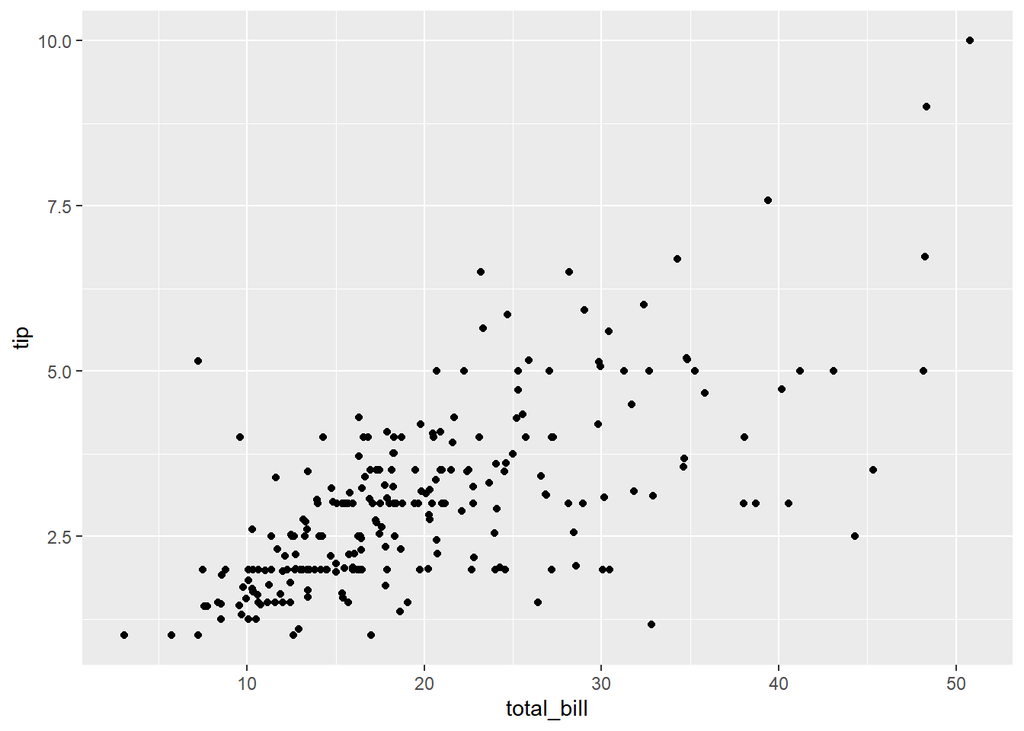

```r
ggplot(tips, aes(x=total_bill, y=tip)) + geom_point()
```

This graph shows us that as the total bill increases so does the tip. This makes sense because people usually tip a percentage of their total bill. Some anomalies would be the data point where the bill was around $7 but the tip was over $5. Another anomaly would be the data point where the total bill was around $33, but the tip was around $1. This could be explained by the satisfaction level of the customers.

```r
pretip_bill <- tips[,1] - tips[,2]
tiprate <- tips[,2]/tips[,7]
tips <- cbind(tips, pretip_bill)
tips <- cbind(tips, tiprate)
head(tips)
```

```
##   total_bill  tip    sex smoker day   time size pretip_bill   tiprate
## 1      16.99 1.01 Female     No Sun Dinner    2       15.98 0.5050000
## 2      10.34 1.66   Male     No Sun Dinner    3        8.68 0.5533333
## 3      21.01 3.50   Male     No Sun Dinner    3       17.51 1.1666667
## 4      23.68 3.31   Male     No Sun Dinner    2       20.37 1.6550000
## 5      24.59 3.61 Female     No Sun Dinner    4       20.98 0.9025000
## 6      25.29 4.71   Male     No Sun Dinner    4       20.58 1.1775000
```

```r
average_tip <- mean(tips[,9])
average_tip
```

```
## [1] 1.212762
```

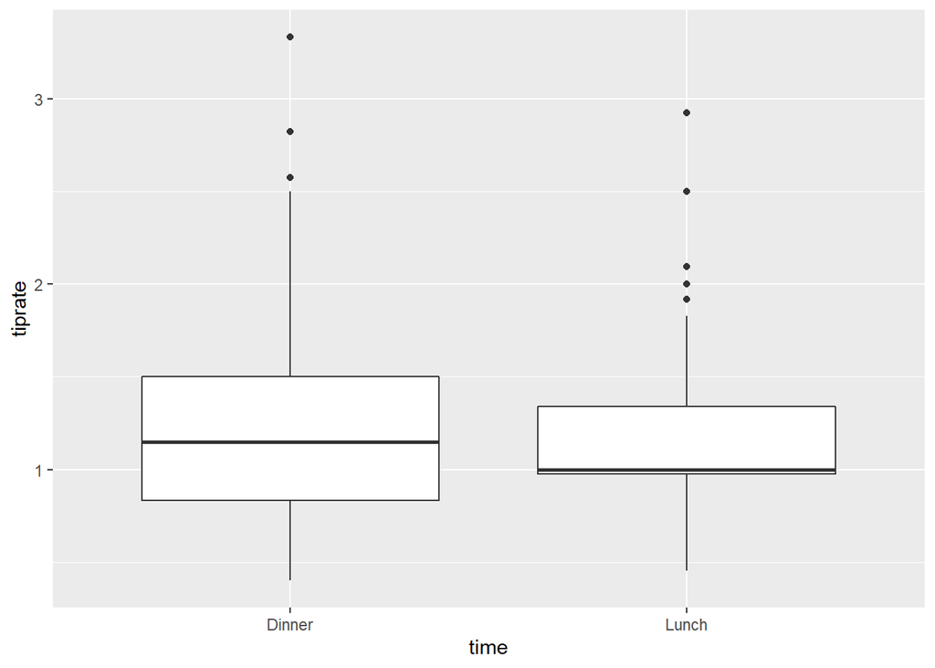

```r
ggplot(tips, aes(x=time, y=tiprate)) + geom_boxplot()
```

These box plots show that the average tip rate is smaller at lunch time than dinner.

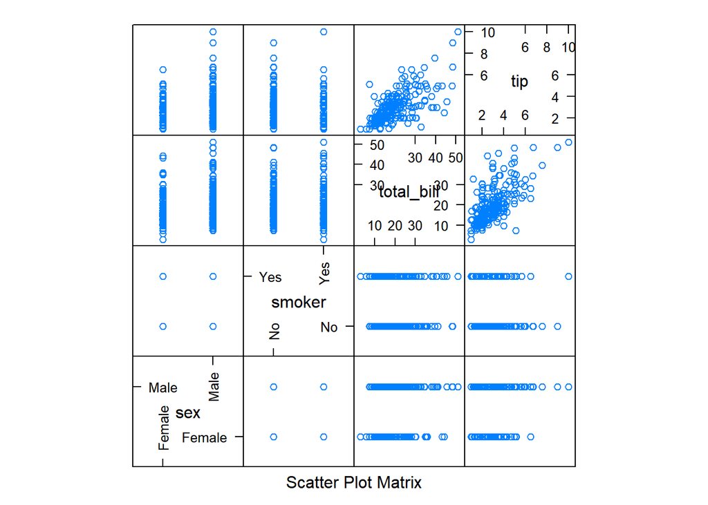

```r
#ggplot(tips, aes(x = sex, y = total_bill)) + geom_col(aes(fill = tip), width = 0.7)
data(tips)
featurePlot(x=tips[,3:4], y=tips[, 1:2], plot = "pairs", auto.key=list(columns=4))
```

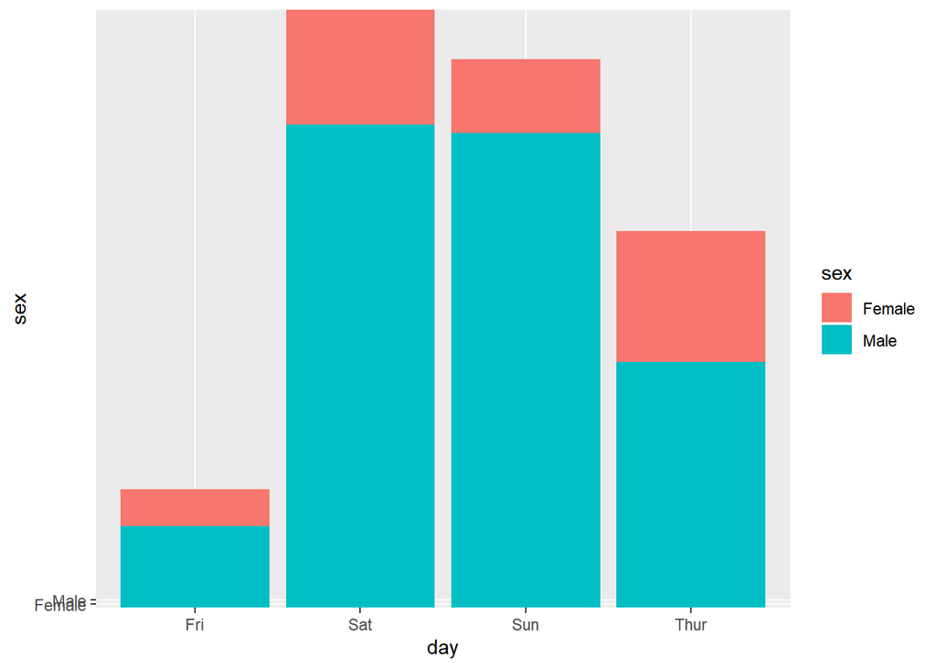

```r
ggplot(tips, aes(x=day, y=sex)) + geom_bar(aes(fill = sex), stat = "identity")
```